Autor ___________ Danilo Filippo Reizel Pereira (DRE 113051728)  
Kaggle __________ https://www.kaggle.com/danilofrp

# Resumo

Este relatório tem como objetivo apresentar as técnicas de pré-processamento empregadas, bem como os modelos construídos, para o trabalho da disciplina de Aprendizado de Máquina (EEL891), do curso de Engenharia Eletrônica e de Computação. A seção de introdução fará um breve resumo das técnicas empregadas neste trabalho, e as seções seguintes apresentarão detalhadamente os passos tomados, jutamente com o código e os resultados obtidos

## Descrição do trabalho

Este trabalho é baseado no desafio do kaggle [House Prices: Advanced Regression Techniques](https://www.kaggle.com/c/house-prices-advanced-regression-techniques). O desafio consiste em um problema de regrssão, no qual deve-se prever o preço de venda de um imóvel na cidade de Ames, Iowa, baseado em diversas características deste imóvel, como área construída, área do terreno, localização do terreno, ano de construção, entre outros. Por apresentar diversas features de natureza variada, torna-se um bom desafio para treinar técnicas de pré-processamento e análise de dados.

## Técnicas utilizadas

### Pré-processamento

Devido ao grande número de features e variabilidade da natureza das mesmas, técnicas aprorpiadas de pré-processamento precisam ser empregadas. De início, removemos algumas amostras consideradas outliers, seja por estarem explicitamente apontadas como outliers na [descrição do dataset](https://ww2.amstat.org/publications/jse/v19n3/decock/DataDocumentation.txt) ou por terem sido consideradas outliers com base em uma anáise crítica das variáveis.

Após a remoção dos outliers, performamos algumas transformações nos dados. Como pode ser observado lendo a descrição do dataset, há um dado (*MSSubClass*) que é categórico apesar de ser representado por valores numéricos. Também é possível perceber que há alguns dados categóricos que possuem uma relação de ordem entre si, como por exemplo aqueles cujas "categorias" são Excellent, Good, Average/Typical, Fair e Poor. Por fim, também transformamos o dado *Neighborhood* em uma variável numérica, pela adição de dados externos, encontrados enquanto se procurava mais informações sobre o dataset. Esses dados (https://ww2.amstat.org/publications/jse/v19n3/decock/AmesResidential.pdf) apresentam um fator multiplicador para cada bairro da cidade, que foi utilizado para normalizar os preços (divide-se o preço de venda pelo fator multiplicador do bairro, após a previsão aplica-se a operação oposta).

Feita a transformação dos dados, tratamos os dados faltantes. Optamos por excluir do modelo as features que apresentam grande quantidade de dados faltantes, como é o caso de *PoolQC* (99,72% de dados faltantes). Para as demais features, técnicas simples de substituição pela moda, para o caso de variáveis categóricas, ou substituição pela mediana, para variáveis numéricas, foram empregadas. Também criamos uma variável extra, a área interna total do imóvel, que apresentou uma grande correlação com o preço. Após esta etapa, verificou-se que algumas variáveis numéricas, bem como a variável alvo, não apresentavam similaridade satisfatória com uma gaussiana, então realizaram-se transformações logp1 e box-cox para reduzir a assimetria das distribuições.

Após esta etapa, foram analisadas as correlações entre as features e a variável alvo, e também entre features. Primeiramente, realzou-se uma transformação nas variáveis *YearBuilt*, *YearRemodAdd* e *GarageYrBlt* para que passassem a representar a idade relativa ao momento da venda, em vez de anos exatos. Depois, analisou-se a correlação entre as variáveis *GarageArea* e *GarageCars*, e percebeu-se notamos uma forte relação entre elas. Optamos por retirar a variável *GarageCars* do modelo, para evitar o input de dados redundantes. Da mesma forma, foram removidas as variáveis *TotRmsAbvGrd*, *GarageAgeAtSale*, *TotalBsmtSF*, *GrLivArea* e *GarageCond*, também por apresentarem forte relação com outras variáveis de entrada. Optou-se também por remover as variáveis que apresentavam correlação menor do que 10% com a saída, por julgar que estas variáveis não seriam boas descritoras do preço de venda, e poderiam agir como ruído.

Por fim, transformamos as variáveis categóricas utilizando o método de *OneHotEncoding*. Durante a aplicação desse método, foi garantido que uma das variáveis *dummy* de cada categoria fosse removida, para evitar a chamada *dummy variable trap*, na qual uma feature pode ser prevista pelas demais. Para o caso especial dos pares de variáveis *(Condition1, Condition2)* e *(Exterior1st, Exterior2nd)*, que representam a mesma feature, foi utilizada uma codificação na qual permitiu-se mais até duas variáveis *dummy* estarem ativas simultaneamente.

## Conclusão

Ao longo do desenvolvimento do trabalho pode-se perceber a importância da etapa de pré-processamento para modelos de machine learning, em especial pode-se notar um impacto nos resultados muito superior ao da modificação dos parâmetros dos modelos. Em particular, os processos que geraram a maior melhora no resultado foram a adição dos dados externos de multiplicador para os bairros, as transformações nos dados para torná-los gaussianos, e a remoção de variáveis pouco relevantes. A adição do perceptron para a realização do ensemble também causou um grande impacto na performance do estimador final.

# Detalhamento

Abaixo, pode-se encontrar a descrição detalhada das decisões tomadas, bem como o código utilizado e os resultados gerados

```python
# Bibliotecas básicas necessárias para o código:
import pandas as pd
import matplotlib.pyplot as plt
import seaborn as sns
import numpy as np
import warnings
warnings.filterwarnings('ignore')
```

## Aquisição dos dados

```python
data_train = pd.read_csv('../data/train.csv')
data_test = pd.read_csv('../data/test.csv')
data_test['SalePrice'] = -1
test_ids = data_test['Id']
```

## Remoção de outliers

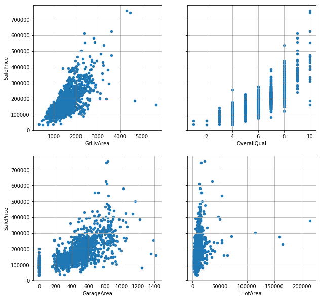

```python
colnames = ['GrLivArea','OverallQual','GarageArea','LotArea']
data = pd.concat([data_train['SalePrice'], data_train[colnames]], axis=1)

fig, axes = plt.subplots(2, 2, figsize=(10, 10))
for i in range(len(colnames)):
    data.plot.scatter(x = colnames[i], y = 'SalePrice', ax = axes[i//2, i%2],
                      sharey = True, grid = True)
```

Podemos perceber alguns outliers pela análise das variáveis *GrLivArea*, *GarageArea* e *LotArea*, no qual as variáveis são muito superiores às demais, porém o preço não segue essa tendência. Removemos tais amostras do dataset

```python
data_train = data_train[data_train['GrLivArea'] < 4000]
data_train = data_train[data_train['GarageArea'] < 1200]
data_train = data_train[data_train['LotArea'] < 100000]

all_data = pd.concat((data_train, data_test))
target = data_train['SalePrice']
```

## Transformações Numéricas/Categóricas

Lendo a descrição do dataset, podemos perceber que MSSubClass é uma variável categórica, apesar de ser tratada numericamente, assim, transformamos em uma string para depois aplicar o LabelEncoder e OneHotEncoder facilmente.

```python
all_data['MSSubClass'] = all_data['MSSubClass'].transform(lambda x: str(x))\
                                               .astype(str)
```

Também podemos perceber que as variáveis *ExterQual*, *ExterCond*, *BsmtQual*, *BsmtCond*, *HeatingQC*, *KitchenQual*, *FireplaceQu*, *GarageQual*, *GarageCond* e *PoolQC*, apesar de a princípio parecerem variáveis categóricas, podem ser representadas por variáveis numéricas, pois seus níveis (NA, Po, Fa, TA, Gd, Ex) tem uma relação de superioridade/inferioridade entre um e outro. Assim, podemos mapeá-los da seguinte forma: {NA: 0, Po: 1, Fa: 2, TA: 3, Gd: 4, Ex: 5}.

O mesmo acontece para as variáveis *LandSlope*, *BsmtExposure*, *BsmtFinType1*, *BsmtFinType2*, *Functional*, *GarageFinish*, *PavedDrive* e *Fence*.

```python
grades_map = {'NA': 0, 'Po': 1, 'Fa': 2, 'TA': 3, 'Gd': 4, 'Ex': 5}
def map_grade(grade):
    if isinstance(grade, float) and np.isnan(grade): return grade
    return grades_map[grade]

landslope_map = {'Gtl': 0, 'Mod': 1, 'Sev': 2}
def map_landslope(slope):
    if isinstance(slope, float) and np.isnan(slope): return slope
    return landslope_map[slope]

bsmtexposure_map = {'No': 0, 'Mn': 1, 'Av': 2, 'Gd': 3}
def map_bsmtexposure(exposure):
    if isinstance(exposure, float) and np.isnan(exposure): return exposure
    return bsmtexposure_map[exposure]

bsmtfintype_map = {'Unf': 0, 'LwQ': 1, 'Rec': 2, 'BLQ': 3, 'ALQ': 4, 'GLQ': 5}
def map_bsmtfintype(fintype):
    if isinstance(fintype, float) and np.isnan(fintype): return fintype
    return bsmtfintype_map[fintype]

functional_map = {'Typ': 0, 'Min1': 1, 'Min2': 2, 'Mod': 3, 'Maj1': 4,
                  'Maj2': 5, 'Sev': 6, 'Sal': 7}
def map_functional(functional):
    if isinstance(functional, float) and np.isnan(functional): return functional
    return functional_map[functional]

garagefin_map = {'Unf': 0, 'RFn': 1, 'Fin': 2}
def map_garagefin(garagefin):
    if isinstance(garagefin, float) and np.isnan(garagefin): return garagefin
    return garagefin_map[garagefin]

pave_map = {'N': 0, 'P': 1, 'Y': 2}
def map_pave(pave):
    if isinstance(pave, float) and np.isnan(pave): return pave
    return pave_map[pave]

fence_map = {'NA': 0, 'MnWw': 1, 'GdWo': 2, 'MnPrv': 3, 'GdPrv': 4}
def map_fence(fence):
    if isinstance(fence, float) and np.isnan(fence): return fence
    return fence_map[fence]

for col in ('ExterQual', 'ExterCond', 'BsmtQual', 'BsmtCond', 'HeatingQC',
            'KitchenQual', 'FireplaceQu', 'GarageQual', 'GarageCond', 'PoolQC'):
    all_data[col] = all_data[col].transform(map_grade).astype(float)

all_data['LandSlope']    = all_data['LandSlope'].transform(map_landslope).astype(float)
all_data['BsmtExposure'] = all_data['BsmtExposure'].transform(map_bsmtexposure).astype(float)
all_data['BsmtFinType1'] = all_data['BsmtFinType1'].transform(map_bsmtfintype).astype(float)
all_data['BsmtFinType2'] = all_data['BsmtFinType2'].transform(map_bsmtfintype).astype(float)
all_data['Functional']   = all_data['Functional'].transform(map_functional).astype(float)
all_data['GarageFinish'] = all_data['GarageFinish'].transform(map_garagefin).astype(float)
all_data['PavedDrive']   = all_data['PavedDrive'].transform(map_pave).astype(float)
all_data['Fence']        = all_data['Fence'].transform(map_fence).astype(float)
```

Por fim, como encontrado na descrição do dataset, podemos utilizar dados auxiliares para transformar os bairros em seus multiplicadores. (https://ww2.amstat.org/publications/jse/v19n3/decock/AmesResidential.pdf)

```python
neighborhood_map = {'CollgCr': 98, 'Veenker': 98, 'Crawfor': 106, 'NoRidge': 101,
                    'Mitchel': 99, 'Somerst': 101, 'NWAmes': 99, 'OldTown': 102,
                    'BrkSide': 106, 'Sawyer': 101, 'NridgHt': 104, 'NAmes': 100,
                    'SawyerW': 98, 'IDOTRR': 102, 'MeadowV': 90, 'Edwards': 98,
                    'Timber': 103, 'Gilbert': 97, 'StoneBr': 104, 'ClearCr': 103,
                    'NPkVill': 109, 'Blmngtn': 105, 'BrDale': 105, 'SWISU': 99 ,
                    'Blueste': 99}
def map_neighborhood(neighborhood):
    if isinstance(neighborhood, float) and np.isnan(neighborhood): return neighborhood
    return neighborhood_map[neighborhood]

all_data['Neighborhood'] = all_data['Neighborhood'].transform(map_neighborhood)\
                                                   .astype(float)
```

```python
numerical_cols = all_data.select_dtypes(include=['int64', 'float64'])\
                                        .drop('Id', axis = 1).columns.values
categorical_cols = all_data.select_dtypes(exclude=['int64', 'float64'])\
                                        .columns.values
```

## Dados Faltantes

Contando os dados faltantes para cada feature:

```python
total = all_data.isnull().sum().sort_values(ascending=False)
percent = (all_data.isnull().sum()*100/all_data.isnull().count())\
                                        .sort_values(ascending=False)
missing_data = pd.concat([total, percent], axis=1, keys=['Total', 'Percent'])
missing_data[missing_data['Total'] > 0].round({'Percent': 2})
```

|  | Total | Percent |
| --- | --- | --- |
| PoolQC | 2899 | 99.72 |
| MiscFeature | 2805 | 96.49 |
| Alley | 2709 | 93.19 |
| Fence | 2337 | 80.39 |
| FireplaceQu | 1419 | 48.81 |
| LotFrontage | 482 | 16.58 |
| GarageCond | 159 | 5.47 |
| GarageYrBlt | 159 | 5.47 |
| GarageFinish | 159 | 5.47 |
| GarageQual | 159 | 5.47 |
| GarageType | 157 | 5.40 |
| BsmtCond | 82 | 2.82 |
| BsmtExposure | 82 | 2.82 |
| BsmtQual | 81 | 2.79 |
| BsmtFinType2 | 80 | 2.75 |
| BsmtFinType1 | 79 | 2.72 |
| MasVnrType | 24 | 0.83 |
| MasVnrArea | 23 | 0.79 |
| MSZoning | 4 | 0.14 |
| Utilities | 2 | 0.07 |
| BsmtHalfBath | 2 | 0.07 |
| BsmtFullBath | 2 | 0.07 |
| Functional | 2 | 0.07 |
| Exterior1st | 1 | 0.03 |
| TotalBsmtSF | 1 | 0.03 |
| BsmtUnfSF | 1 | 0.03 |
| BsmtFinSF2 | 1 | 0.03 |
| GarageArea | 1 | 0.03 |
| KitchenQual | 1 | 0.03 |
| GarageCars | 1 | 0.03 |
| BsmtFinSF1 | 1 | 0.03 |
| Exterior2nd | 1 | 0.03 |
| SaleType | 1 | 0.03 |
| Electrical | 1 | 0.03 |

Escolhemos ignorar as features com mais de 30% dos dados faltantes, pois com tantos dados faltantes a feature não é uma boa descritora do preço de venda ou então uma tentativa de aproximação pode gerar muitos erros.

Para o caso da piscina, como há apenas 5 amostras no dataset de treino, também ignoramos a variável *PoolArea*.

```python
all_data.drop(missing_data[missing_data['Percent'] > 30].index,
              axis = 1, inplace = True)
all_data.drop('PoolArea', axis = 1, inplace = True)
```

Para a feature *LotFrontage*, assumimos que a area frontal do terreno é igual à mediana da área frontal dos terrenos da mesma vizinhança da amostra

```python
all_data['LotFrontage'] = all_data.groupby('Neighborhood')['LotFrontage']\
                                .transform(lambda x: x.fillna(x.median()))
```

Para as informações relativas à garagem, os dados faltantes indicam que a casa não possui garagem. Assim, substituimos os valores por None (categóricos) ou 0 (numéricos). Para o caso do ano de construção da garagem, repetimos o ano de construção da casa. Foi observado que no dataset de treino existe uma amostra na qual a feature *GarageYrBlt* apresenta ano de construção 2207, o que é impossível. Foi assumido que tal valor foi um erro de digitação e seu valor foi substituído por 2007.

```python
for column in ('GarageType', 'GarageFinish', 'GarageQual',
               'GarageCond', 'GarageArea', 'GarageCars'):
    if column in numerical_cols:
        all_data[column].fillna(0, inplace = True)
    else:
        all_data[column].fillna('None', inplace = True)

all_data['GarageYrBlt'].fillna(all_data['YearBuilt'], inplace = True)
index = all_data[all_data['GarageYrBlt'] > max(all_data['YearBuilt'])].index
all_data.iloc[index]['GarageYrBlt'] = 2007
```

Para as variáveis *Bsmt[...]*, realizamos o tratamento de forma similar ao tratamento das variáveis de garagem

```python
for column in ('BsmtFinSF1', 'BsmtFinSF2', 'BsmtUnfSF','TotalBsmtSF',
               'BsmtFullBath', 'BsmtHalfBath', 'BsmtQual', 'BsmtCond',
               'BsmtExposure', 'BsmtFinType1', 'BsmtFinType2'):
    if column in numerical_cols:
        all_data[column].fillna(0, inplace = True)
    else:
        all_data[column].fillna('None', inplace = True)
```

Para as variáveis *MasVnrType* e *MasVnrArea*, dados faltantes representam que não há alvenaria, então substituímos por None ou 0

```python
all_data["MasVnrType"].fillna("None", inplace = True)
all_data["MasVnrArea"].fillna(0, inplace = True)
```

Para as variaveis *MSZoning*, *SaleType*, *Utilities* e *Functional* substituimos pela moda

```python
all_data['MSZoning'].fillna(all_data['MSZoning'].mode()[0], inplace = True)
all_data['SaleType'].fillna(all_data['SaleType'].mode()[0], inplace = True)
all_data['Utilities'].fillna(all_data['Utilities'].mode()[0], inplace = True)
all_data['Functional'].fillna(all_data['Functional'].mode()[0], inplace = True)
```

Para as variáveis *Electrical*, *Exterior1st*, *Exterior2nd* e *KitchenQual*, utilizamos a moda das construções na mesma vizinhança da amostra faltante

```python
for column in ('Electrical', 'Exterior1st', 'Exterior2nd', 'KitchenQual'):
    all_data[column] = all_data.groupby('Neighborhood')[column]\
                            .transform(lambda x: x.fillna(x.mode()[0]))
```

Verificando se todos os dados faltantes foram tratados:

```python
total_after = all_data.isnull().sum().sort_values(ascending=False)
if total_after[total_after > 0].empty:
    print('Não há mais dados faltantes')
else:
    print(total_after[total_after > 0])
```

```
Não há mais dados faltantes
```

Por fim, adicionamos uma variável auxiliar, a área interna total do imóvel (diferente de *GrLivArea*, que desconsidera a área no subsolo)

```python
all_data['TotalSF'] = all_data['TotalBsmtSF']\
                      + all_data['1stFlrSF']\
                      + all_data['2ndFlrSF']
```

Separando novamente o dataset em treino e teste:

```python
data_train = all_data[all_data['SalePrice'] > 0]
data_test = all_data[all_data['SalePrice'] < 0]

numerical_cols = all_data.select_dtypes(include=['int64', 'float64'])\
                                    .drop('Id', axis = 1).columns.values
categorical_cols = all_data.select_dtypes(exclude=['int64', 'float64'])\
                                    .columns.values
```

Realizando a normalização do preço de venda pelo multiplicador do bairro:

```python
data_train['SalePrice'] = data_train['SalePrice']*100/data_train['Neighborhood']
target = data_train['SalePrice']
```

## Transformação nas variáveis numéricas

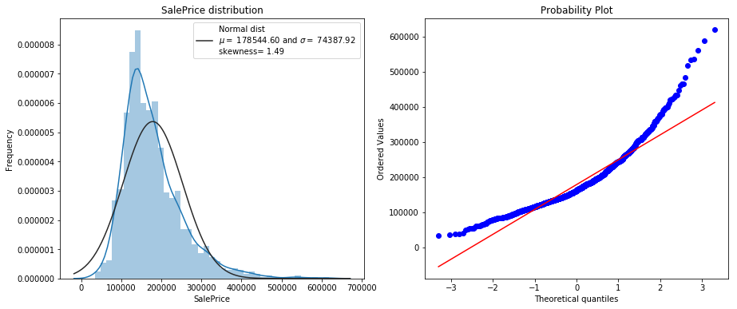

```python
from scipy import stats
from scipy.stats import norm, skew

fig, axes = plt.subplots(1, 2, figsize=(15, 6))
sns.distplot(target, fit = norm, ax = axes[0]);
(mu, sigma) = norm.fit(target)

axes[0].legend(['Normal dist \n$\mu=$ {:.2f} and $\sigma=$ {:.2f} \nskewness= {:.2f}'
                                    .format(mu, sigma, skew(target))],
                loc='best')
axes[0].set_ylabel('Frequency')
axes[0].set_title('SalePrice distribution')

stats.probplot(target, plot = axes[1])
plt.show()
```

Podemos perceber que a variável alvo não se aproxima da distribuição normal, e tem uma cauda longa para a direita. É recomendável realizar uma transformação nos dados para aproximá-los de uma gaussiana, o que costuma melhorar a performance dos modelos. Para isso, será utilizada a transformação logp1. Como o desafio no kaggle avalia o RMSLE, ao realizar esta transformação na saída, podemos avaliar os modelos utilizando o RMSE como métrica de erro, sem se preocupar em fazer a transformação inversa da variável, a parcela log já foi aplicada.

```python
target = np.log1p(target)
```

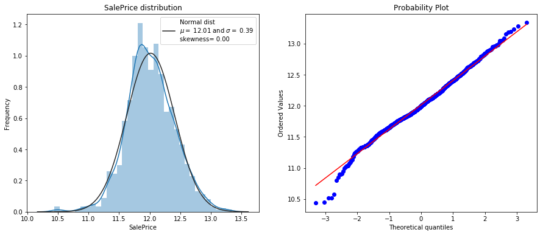

```python
fig, axes = plt.subplots(1, 2, figsize=(15, 6))
sns.distplot(target, fit = norm, ax = axes[0]);

(mu, sigma) = norm.fit(target)
axes[0].legend(['Normal dist \n$\mu=$ {:.2f} and $\sigma=$ {:.2f}\nskewness= {:.2f}'
                                                .format(mu, sigma, skew(target))],
               loc='best')
axes[0].set_ylabel('Frequency')
axes[0].set_title('SalePrice distribution')

res = stats.probplot(target, plot = axes[1])
plt.show()
```

Pode-se notar que a transformação torna a distribuição dos dados mais próxima da gaussiana.

Fazemos o mesmo para as demais features que apresentam skewness superior a 1. Para estas features, utilizamos a transformação de Box-Cox, que pode ser considerada uma generalização da transformação log1p.

```python
skewed_feats = all_data[numerical_cols].apply(lambda x: skew(x.dropna()))\
                                       .sort_values(ascending=False)
skewness = pd.DataFrame({'Skew' :skewed_feats})
skewness[skewness['Skew'] > 0.75]
```

|  | Skew |
| --- | --- |
| MiscVal | 21.934924 |
| LowQualFinSF | 12.063406 |
| 3SsnPorch | 11.352135 |
| LandSlope | 4.971924 |
| Functional | 4.952203 |
| KitchenAbvGr | 4.292019 |
| BsmtFinSF2 | 4.154322 |
| EnclosedPorch | 3.994600 |
| BsmtHalfBath | 3.951078 |
| ScreenPorch | 3.937129 |
| LotArea | 3.616277 |
| BsmtFinType2 | 3.377555 |
| MasVnrArea | 2.611175 |
| OpenPorchSF | 2.528156 |
| WoodDeckSF | 1.844393 |
| ExterCond | 1.312569 |
| 1stFlrSF | 1.261755 |
| BsmtExposure | 1.250405 |
| LotFrontage | 1.082814 |
| SalePrice | 0.992542 |
| GrLivArea | 0.983865 |
| BsmtFinSF1 | 0.978732 |
| TotalSF | 0.942529 |
| BsmtUnfSF | 0.915030 |
| 2ndFlrSF | 0.840496 |
| ExterQual | 0.783284 |
| TotRmsAbvGrd | 0.751681 |

```python
from scipy.special import boxcox1p
skewed_features = skewness[skewness['Skew'] > 1].index
lam = 0.15
for feat in skewed_features:
    all_data[feat] = boxcox1p(all_data[feat], lam)
```

```python
data_train = pd.concat([all_data[all_data['SalePrice'] > 0]\
                        .drop('SalePrice', axis = 1), target], axis = 1)\
                        .dropna()
target = data_train['SalePrice']
data_test = all_data[all_data['SalePrice'] < 0].copy()
```

## Análise das variáveis numéricas

```python
removed_cols = []
```

### Analisando as relações entre *Sales price* e as variáveis temporais:

|  | SalePrice | YearBuilt | YearRemodAdd | GarageYrBlt | YrSold |
| --- | --- | --- | --- | --- | --- |
| SalePrice | 1.000000 | 0.609820 | 0.576678 | 0.590544 | 0.033360 |
| YearBuilt | 0.609820 | 1.000000 | 0.591399 | 0.845548 | 0.013557 |
| GarageYrBlt | 0.590544 | 0.845548 | 0.605168 | 1.000000 | 0.009976 |
| YearRemodAdd | 0.576678 | 0.591399 | 1.000000 | 0.605168 | 0.037351 |
| YrSold | 0.033360 | 0.013557 | 0.037351 | 0.009976 | 1.000000 |

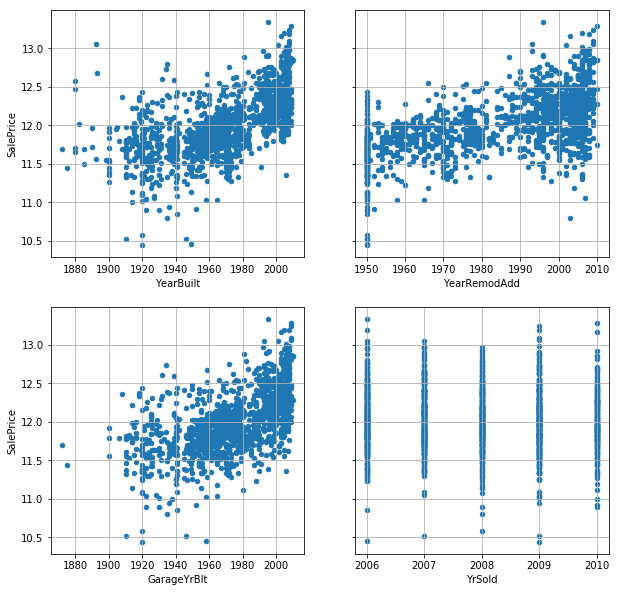

```python
colnames = ['YearBuilt', 'YearRemodAdd', 'GarageYrBlt', 'YrSold']
data = pd.concat([data_train['SalePrice'], data_train[colnames]], axis=1)

fig, axes = plt.subplots(2, 2, figsize=(10, 10))
for i in range(len(colnames)):
    data.plot.scatter(x = colnames[i], y = 'SalePrice', ax = axes[i//2, i%2],
                      sharey = True, grid = True)

abs(data_train[['SalePrice','YearBuilt','YearRemodAdd','GarageYrBlt','YrSold']]\
                        .corr())\
                        .sort_values(by = 'SalePrice', ascending = False)
```

Realizando uma transformação nas variáveis que representam anos para que passem a representar idade no momento da venda

- newVar = YrSol - oldVar

```python
data_train['AgeAtSale'] = data_train['YrSold'] - data_train['YearBuilt']
data_train['AgeRemodAtSale'] = data_train['YrSold'] - data_train['YearRemodAdd']
data_train['GarageAgeAtSale'] = data_train['YrSold'] - data_train['GarageYrBlt']

data_test['AgeAtSale'] = data_test['YrSold'] - data_test['YearBuilt']
data_test['AgeRemodAtSale'] = data_test['YrSold'] - data_test['YearRemodAdd']
data_test['GarageAgeAtSale'] = data_test['YrSold'] - data_test['GarageYrBlt']

removed_cols.extend(['YearBuilt', 'YearRemodAdd', 'GarageYrBlt'])
data_train.drop(['YearBuilt', 'YearRemodAdd', 'GarageYrBlt'], axis = 1, inplace = True)

data_train.drop(['SalePrice'], axis = 1, inplace = True)
data_train['SalePrice'] = target
```

|  | SalePrice | AgeAtSale | AgeRemodAtSale | GarageAgeAtSale | YrSold |
| --- | --- | --- | --- | --- | --- |
| SalePrice | 1.000000 | 0.610334 | 0.579021 | 0.591178 | 0.033360 |
| AgeAtSale | 0.610334 | 1.000000 | 0.592737 | 0.846066 | 0.057514 |
| GarageAgeAtSale | 0.591178 | 0.846066 | 0.606305 | 1.000000 | 0.060425 |
| AgeRemodAtSale | 0.579021 | 0.592737 | 1.000000 | 0.606305 | 0.027173 |
| YrSold | 0.033360 | 0.057514 | 0.027173 | 0.060425 | 1.000000 |

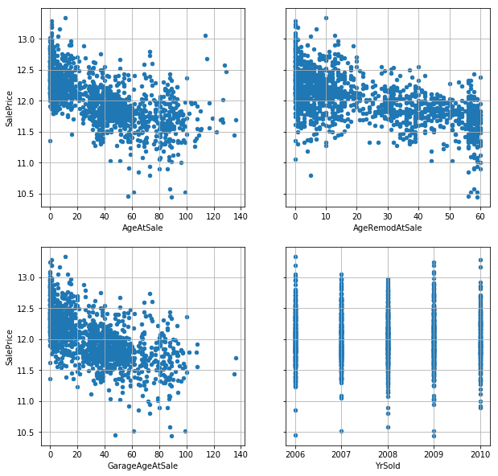

```python
colnames = ['AgeAtSale','AgeRemodAtSale','GarageAgeAtSale','YrSold']
data = pd.concat([data_train['SalePrice'], data_train[colnames]], axis=1)

fig, axes = plt.subplots(2, 2, figsize=(10, 10))
for i in range(len(colnames)):
    data.plot.scatter(x = colnames[i], y = 'SalePrice', ax = axes[i//2, i%2],
                      sharey = True, grid = True)

abs(data_train[['SalePrice','AgeAtSale','AgeRemodAtSale','GarageAgeAtSale','YrSold']]\
                            .corr())\
                            .sort_values(by = 'SalePrice', ascending = False)
```

Pode-se notar que a correlção entre as novas variáveis e o preço de venda é levemente superior (em módulo) do que as variáveis originais.  
Pode-se também perceber que a variável YrSold tem baixa correlação SalePrice, logo podemos removê-la do dataset.

```python
removed_cols.append('YrSold')
data_train.drop('YrSold', axis = 1, inplace = True)
```

### Analisando as variáveis de garagem

Pela descrição do dataset, 'GarageCars' e 'GarageArea' parecem ser informações redundantes.

|  | SalePrice | GarageArea | GarageCars |
| --- | --- | --- | --- |
| SalePrice | 1.000000 | 0.668177 | 0.684840 |
| GarageCars | 0.684840 | 0.889933 | 1.000000 |
| GarageArea | 0.668177 | 1.000000 | 0.889933 |

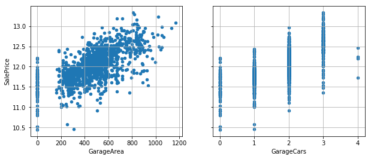

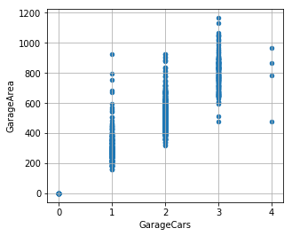

```python
colnames = ['GarageArea', 'GarageCars']
data = pd.concat([data_train['SalePrice'], data_train[colnames]], axis=1)

fig, axes = plt.subplots(1, len(colnames), figsize=(10, 4))
for i in range(len(colnames)):
    data.plot.scatter(x = colnames[i], y = 'SalePrice', ax = axes[i],
                      sharey = True, grid = True)

data.plot.scatter(x = 'GarageCars', y = 'GarageArea', grid = True,
                  figsize=(4.75, 4))

data_train[['SalePrice','GarageArea','GarageCars']]\
                            .corr()\
                            .sort_values(by = 'SalePrice', ascending = False)
```

Podemos ver que *GarageCars* e *GarageArea* apresentam forte correlação entre si. Apesar de *GarageCars* apresentar uma correlação com o preço de venda levemente superior do que *GarageArea* optamos por manter a variável *GarageArea*, por ser contínua, na esperança de que esta se encaixe melhor nos modelos.

```python
removed_cols.append('GarageCars')
data_train.drop('GarageCars', axis = 1, inplace = True)
```

### Correlação entre demais variáveis

Visualizando algumas correlações importantes:

|  | SalePrice | TotalSF | OverallQual | GrLivArea | LotArea |
| --- | --- | --- | --- | --- | --- |
| SalePrice | 1.000000 | 0.815902 | 0.815105 | 0.714128 | 0.409011 |
| TotalSF | 0.815902 | 1.000000 | 0.674258 | 0.860378 | 0.428950 |
| OverallQual | 0.815105 | 0.674258 | 1.000000 | 0.583466 | 0.176907 |
| GrLivArea | 0.714128 | 0.860378 | 0.583466 | 1.000000 | 0.388453 |
| LotArea | 0.409011 | 0.428950 | 0.176907 | 0.388453 | 1.000000 |

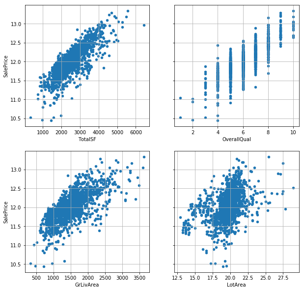

```python
colnames = ['TotalSF','OverallQual','GrLivArea','LotArea']
data = pd.concat([data_train['SalePrice'], data_train[colnames]], axis=1)

fig, axes = plt.subplots(2, 2, figsize=(10, 10))
for i in range(len(colnames)):
    data.plot.scatter(x = colnames[i], y = 'SalePrice', ax = axes[i//2, i%2],
                      sharey = True, grid = True)

abs(data_train[['SalePrice','TotalSF','OverallQual','GrLivArea','LotArea']]\
                                .corr())\
                                .sort_values(by = 'SalePrice', ascending = False)
```

Construindo a matriz de correlação:

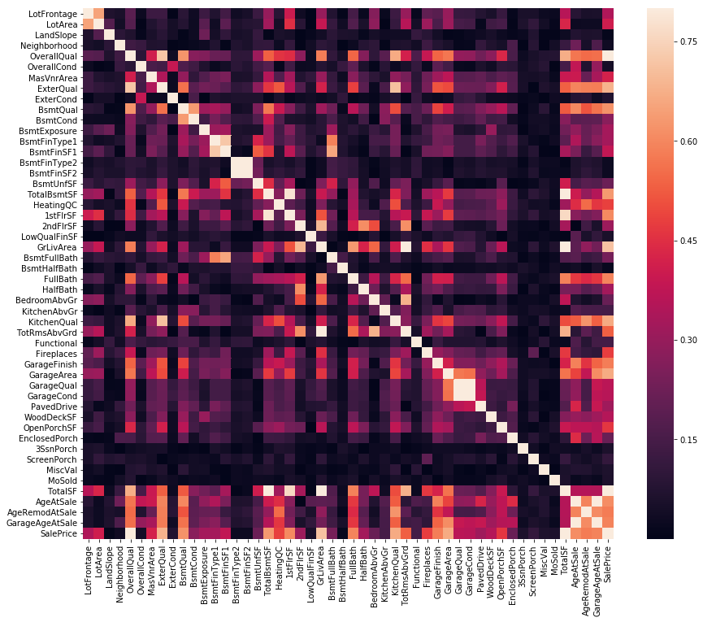

```python
corrmat = abs(data_train.drop('Id', axis = 1).corr())
f, ax = plt.subplots(figsize=(15, 12))
sns.heatmap(corrmat, vmax=.8, square=True);
```

Analisando em detalhes alguns pares de variáveis com forte correlação:

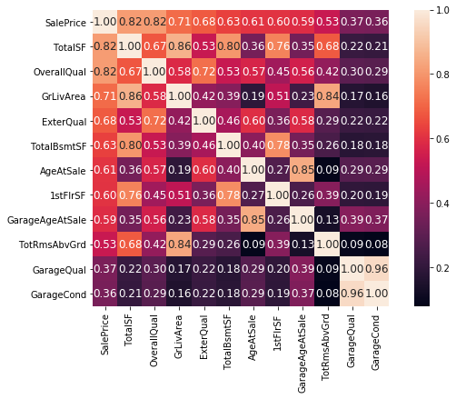

```python
features = ['SalePrice','AgeAtSale','GarageAgeAtSale','TotalSF',
            'GrLivArea','TotRmsAbvGrd','TotalBsmtSF','1stFlrSF',
            'OverallQual','ExterQual','GarageQual','GarageCond']
fig, ax = plt.subplots(figsize=(10,6))
corrmat = abs(data_train[features].corr())
cols = corrmat.nlargest(len(features), 'SalePrice').index
cm = abs(np.corrcoef(data_train[cols].values.T))
hm = sns.heatmap(cm, cbar=True, annot=True, square=True, fmt='.2f',
                 annot_kws={'size': 12}, yticklabels=cols.values,
                 xticklabels=cols.values)
```

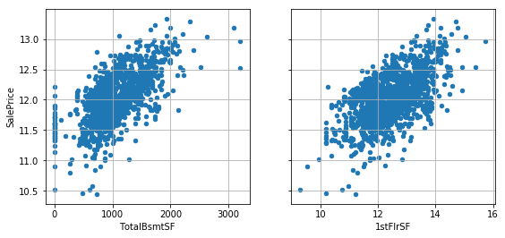

```python
colnames = ['TotalBsmtSF', '1stFlrSF']
data = pd.concat([data_train['SalePrice'], data_train[colnames]], axis=1)

fig, axes = plt.subplots(1, 2, figsize=(9, 4))
for i in range(len(colnames)):
    data.plot.scatter(x = colnames[i], y = 'SalePrice', ax = axes[i],
                      sharey = True, grid = True)
```

```python
data_train.drop(['TotRmsAbvGrd', 'GarageAgeAtSale', 'TotalBsmtSF',
                 'GrLivArea', 'GarageCond'],
                axis = 1, inplace = True)
removed_cols.extend(['TotRmsAbvGrd', 'GarageAgeAtSale', 'TotalBsmtSF',
                     'GrLivArea', 'GarageCond'])
```

Serão removidas também quaisquer variáveis que apresentem correlação menor do que 10% com o preço de venda.

```python
neighborhood_train = data_train['Neighborhood']
variables_correlation = abs(data_train.drop('Id', axis = 1)\
                                .corr()['SalePrice'])\
                                .sort_values(ascending = False)
data_train.drop(variables_correlation[variables_correlation <= 0.1].index,
                axis = 1, inplace = True)
removed_cols.extend(variables_correlation[variables_correlation <= 0.1].index)

print(str(len(data_train.drop('Id', axis = 1)
              .select_dtypes(include=['int64', 'float64']).columns))
                                  + ' features numericas restantes: ')
print(data_train.drop('Id', axis = 1)\
          .select_dtypes(include=['int64', 'float64']).columns.values)
```

```
34 features numericas restantes:
['LotFrontage' 'LotArea' 'OverallQual' 'MasVnrArea' 'ExterQual' 'BsmtQual'
 'BsmtCond' 'BsmtExposure' 'BsmtFinType1' 'BsmtFinSF1' 'BsmtUnfSF'
 'HeatingQC' '1stFlrSF' '2ndFlrSF' 'BsmtFullBath' 'FullBath' 'HalfBath'
 'BedroomAbvGr' 'KitchenAbvGr' 'KitchenQual' 'Functional' 'Fireplaces'
 'GarageFinish' 'GarageArea' 'GarageQual' 'PavedDrive' 'WoodDeckSF'
 'OpenPorchSF' 'EnclosedPorch' 'ScreenPorch' 'TotalSF' 'AgeAtSale'
 'AgeRemodAtSale' 'SalePrice']
```

Visualizando a correlação entre as features numéricas restantes:

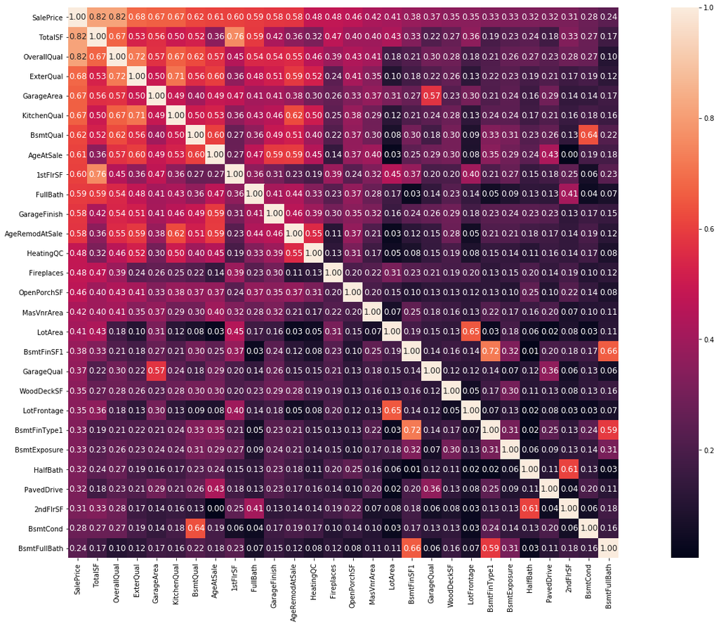

```python
fig, ax = plt.subplots(figsize=(28,15))
k = 28
corrmat = abs(data_train.drop('Id', axis = 1).corr())
cols = corrmat.nlargest(k, 'SalePrice').index
cm = abs(np.corrcoef(data_train[cols].values.T))
sns.heatmap(cm, cbar=True, annot=True, square=True, fmt='.2f',
            annot_kws={'size': 12}, yticklabels=cols.values,
            xticklabels=cols.values);
```

```python
numerical_cols = data_train.drop(['Id', 'SalePrice'], axis = 1)\
                        .select_dtypes(include=['int64', 'float64'])\
                        .columns.values
categorical_cols = data_train.select_dtypes(exclude=['int64', 'float64'])\
                        .columns.values
print(str(len(numerical_cols)) + ' numerical features remaining: ')
print(numerical_cols)
```

```
33 numerical features remaining:
['LotFrontage' 'LotArea' 'OverallQual' 'MasVnrArea' 'ExterQual' 'BsmtQual'
 'BsmtCond' 'BsmtExposure' 'BsmtFinType1' 'BsmtFinSF1' 'BsmtUnfSF'
 'HeatingQC' '1stFlrSF' '2ndFlrSF' 'BsmtFullBath' 'FullBath' 'HalfBath'
 'BedroomAbvGr' 'KitchenAbvGr' 'KitchenQual' 'Functional' 'Fireplaces'
 'GarageFinish' 'GarageArea' 'GarageQual' 'PavedDrive' 'WoodDeckSF'
 'OpenPorchSF' 'EnclosedPorch' 'ScreenPorch' 'TotalSF' 'AgeAtSale'
 'AgeRemodAtSale']
```

```python
neighborhood_test = data_test['Neighborhood']
data_test.drop(removed_cols, axis = 1, inplace = True)
all_data = pd.concat((data_train.drop(['Id', 'SalePrice'], axis = 1),
                      data_test.drop(['Id', 'SalePrice'], axis = 1)))
print('Train shape: ' + str(data_train.drop(['Id', 'SalePrice'], axis = 1).shape))
print('Test shape: ' + str(data_test.drop(['Id', 'SalePrice'], axis = 1).shape))
```

```
Train shape: (1448, 56)
Test shape: (1459, 56)
```

## Tratamento dos dados categóricos

```python
all_data = pd.concat((data_train, data_test))
print('O dataset contém {} variaveis categoricas: '
                      .format(len(categorical_cols)))
print(categorical_cols)
```

```
O dataset contém 23 variaveis categoricas:
['MSSubClass' 'MSZoning' 'Street' 'LotShape' 'LandContour' 'Utilities'
 'LotConfig' 'Condition1' 'Condition2' 'BldgType' 'HouseStyle' 'RoofStyle'
 'RoofMatl' 'Exterior1st' 'Exterior2nd' 'MasVnrType' 'Foundation'
 'Heating' 'CentralAir' 'Electrical' 'GarageType' 'SaleType'
 'SaleCondition']
```

As features *Condition1* e *Contition2*, assim como *Exterior1st* e *Exterior2nd*, descrevem as mesmas categorias, portanto podem ser codificados nas mesmas variáveis *dummy*. Para o restante das features, podemos utilizar a função *get_dummies* do *pandas*, já que nossos dados já estão devidamente tratados. Utilizando o parâmetro *drop_first = True*, evitamos criar colunas linearmente dependentes nesse processo. As colunas *Exterior1st* e *Exterior2nd* apresentavam alguns erros de grafia em algumas classes, que foram corrigidos como pode ser visto no código abaixo.

```python
def get_conditions_dummies(data):
    cond1 = pd.get_dummies(data['Condition1'])
    cond2 = pd.get_dummies(data['Condition2'])

    for cond in ('Artery', 'Feedr', 'Norm', 'PosA', 'PosN',
                 'RRAe', 'RRAn', 'RRNe', 'RRNn'):
        if cond not in cond1.columns:
            cond1[cond] = 0
        if cond not in cond2.columns:
            cond2[cond] = 0

    return (((cond1 + cond2) > 0)*1).drop('RRNe', axis = 1).astype(int)

def get_exterior_dummies(data):
    data = data[['Exterior1st', 'Exterior2nd']]\
                    .replace({'Brk Cmn': 'BrkComm',
                              'CmentBd': 'CemntBd',
                              'Wd Shng': 'WdShing'})
    ext1 = pd.get_dummies(data['Exterior1st'])
    ext2 = pd.get_dummies(data['Exterior1st'])

    for ext in ('AsbShng', 'AsphShn', 'BrkComm', 'BrkFace',
                'CBlock', 'CemntBd', 'HdBoard', 'ImStucc',
                'MetalSd', 'Other', 'Plywood', 'Stone',
                'Stucco', 'VinylSd', 'Wd Sdng', 'WdShing'):
        if ext not in ext1.columns:
            ext1[ext] = 0
        if ext not in ext2.columns:
            ext2[ext] = 0

    return (((ext1 + ext2) > 0)*1).drop('BrkComm', axis = 1)\
                                  .drop('Other', axis = 1).astype(int)

condition = get_conditions_dummies(all_data)
exterior = get_exterior_dummies(all_data)
all_data = all_data.drop(['Condition1', 'Condition2',
                          'Exterior1st', 'Exterior2nd'], axis = 1)
all_data = pd.concat([pd.get_dummies(all_data,drop_first = True),
                      condition, exterior], axis = 1)
```

```python
data_train = all_data[all_data['SalePrice'] > 0].drop('Id', axis = 1)
data_test = all_data[all_data['SalePrice'] < 0].drop(['Id', 'SalePrice'], axis = 1)
print('Train shape: ' + str(data_train.shape))
print('Test shape: ' + str(data_test.shape))
```

```
Train shape: (1448, 146)
Test shape: (1459, 145)
```

Terminamos o pré-processamento com 145 features

## Modelos

```python
from sklearn.preprocessing import RobustScaler
from sklearn.metrics import mean_squared_error
from sklearn.model_selection import KFold, cross_val_score, train_test_split
from sklearn.pipeline import make_pipeline

if 'SalePrice' in data_train.columns:
    data_train.drop('SalePrice', axis = 1, inplace = True)
```

Primeiro, os dados serão transformados para que possam servir de entrada aos modelos. Utilizamos o *RobustScaler* para realizar o escalamento, e separamos 25% dos dados para servir de conjunto de validação.  
Também preparamos um dataset para salvar os resultados dos modelos treinados.

```python
x_scaler = RobustScaler()
y_scaler = RobustScaler()

x = x_scaler.fit_transform(data_train)
x_test = x_scaler.transform(data_test)
y = y_scaler.fit_transform(target.values.reshape(-1, 1))

x_train, x_val, y_train, y_val = train_test_split(x, y, test_size = 0.25)

results = pd.DataFrame([], columns = ['mean', 'std'])
```

Depois, definimos uma função de validação cruzada para avaliar o desempenho dos modelos.

```python
#Validation function
n_folds = 5

def rmsle_cv(model):
    kf = KFold(n_folds, shuffle=True).get_n_splits(data_train.values)
    rmse= np.sqrt(-cross_val_score(model, data_train.values, target.values.reshape(-1, 1),
                                   scoring="neg_mean_squared_error", cv = kf))
    return(rmse)
```

A seguir, criamos os modelos desejados:

### Lasso Regression

```python
from sklearn.linear_model import Lasso

lasso = make_pipeline(RobustScaler(), Lasso(alpha =0.0005))
score = rmsle_cv(lasso)
results.loc['Lasso'] = [score.mean(), score.std()]
```

### ElasticNet

```python
from sklearn.linear_model import ElasticNet

elasticNet = make_pipeline(RobustScaler(), ElasticNet(alpha=0.0005, l1_ratio=.9))
score = rmsle_cv(elasticNet)
results.loc['ElasticNet'] = [score.mean(), score.std()]
```

### Kernel Ridge Regression

```python
from sklearn.kernel_ridge import KernelRidge

KRR = KernelRidge(alpha=0.6, kernel='polynomial', degree=2, coef0=2.5)
score = rmsle_cv(KRR)
results.loc['KRR'] = [score.mean(), score.std()]
```

### Gradient Boost

```python
from sklearn.ensemble import GradientBoostingRegressor

GBoost = GradientBoostingRegressor(n_estimators=3000, learning_rate=0.05,
                                   max_depth=4, max_features='sqrt',
                                   min_samples_leaf=15, min_samples_split=10,
                                   loss='huber')
score = rmsle_cv(GBoost)
results.loc['GBoost'] = [score.mean(), score.std()]
```

### XGBoost

```python
import xgboost as xgb

XGB = xgb.XGBRegressor(colsample_bytree=0.4603, gamma=0.0468,
                             learning_rate=0.05, max_depth=3,
                             min_child_weight=1.7817, n_estimators=2200,
                             reg_alpha=0.4640, reg_lambda=0.8571,
                             subsample=0.5213, silent=1,
                             random_state =7, nthread = -1)
score = rmsle_cv(XGB)
results.loc['XGB'] = [score.mean(), score.std()]
```

### LGBoost

```python
import lightgbm as lgb

LGB = lgb.LGBMRegressor(objective='regression',num_leaves=5,
                              learning_rate=0.05, n_estimators=720,
                              max_bin = 55, bagging_fraction = 0.8,
                              bagging_freq = 5, feature_fraction = 0.2319,
                              feature_fraction_seed=9, bagging_seed=9,
                              min_data_in_leaf =6, min_sum_hessian_in_leaf = 11)
score = rmsle_cv(LGB)
results.loc['LGB'] = [score.mean(), score.std()]
```

### Bayesian Ridge

```python
from sklearn.linear_model import BayesianRidge

BayRidge = BayesianRidge()
score = rmsle_cv(BayRidge)
results.loc['BayRidge'] = [score.mean(), score.std()]
```

### Support Vector Regression

```python
from sklearn.svm import SVR

svr = SVR(kernel='rbf', degree=3, gamma='auto', coef0=0.0,
          tol=0.001, C=1.0, epsilon=0.1, shrinking=True,
          cache_size=200, verbose=False, max_iter=-1)
score = rmsle_cv(svr)
results.loc['SVR'] = [score.mean(), score.std()]
```

### Random Forest Regressor

```python
from sklearn.ensemble import RandomForestRegressor

RFR = RandomForestRegressor(n_estimators = 100)
score = rmsle_cv(RFR)
results.loc['RandomForest'] = [score.mean(), score.std()]
```

Visualizando o sresultados de cada modelo:

```python
results.sort_values(by = 'mean')
```

|  | mean | std |
| --- | --- | --- |
| ElasticNet | 0.115362 | 0.002230 |
| Lasso | 0.115723 | 0.002242 |
| BayRidge | 0.116072 | 0.002182 |
| LGB | 0.120155 | 0.005095 |
| XGB | 0.121937 | 0.003847 |
| GBoost | 0.122609 | 0.005987 |
| RandomForest | 0.138791 | 0.004747 |
| KRR | 0.250258 | 0.024629 |
| SVR | 0.389949 | 0.015000 |

Pode-se notar que o KRR e o SVR apresentaram um desempenho consideravelmente inferior quando comparados aos demais modelos.

### Ensemble de modelos

Treinamos um perceptron para atuar como combinador linear dos resultados dos melhores modelos

```python
from keras.models import Sequential
from keras.layers import Dense
from keras.callbacks import EarlyStopping
from keras import backend as K

class Ensemble():
    def __init__(self, models):
        K.clear_session()
        self.models = models
        self.ensemble_model = Sequential([Dense(1, activation = 'linear',
                                                input_dim = len(models))
                                         ])
        self.ensemble_model.compile(optimizer='sgd', loss='mse')
        self.early_stopping = EarlyStopping(monitor='val_loss', patience=10)
        self.x_scaler = RobustScaler()
        self.y_scaler = RobustScaler()

    def fit(self, x, y):
        x = self.x_scaler.fit_transform(x.values)
        y = self.y_scaler.fit_transform(y.values.reshape(-1, 1))
        predictions = []
        i = 0
        for split in KFold(len(self.models), shuffle=True).split(x):
            self.models[i].fit(x[split[0]], y[:, 0][split[0]])
            predictions.append(self.models[i].predict(x))
            i += 1
        predictions_reshape = [[]]*len(x)
        for i in range(len(x)):
            aux = [];
            for j in range(len(predictions)):
                aux.append(predictions[j][i])
            predictions_reshape[i] = aux
        predictions_reshape = np.array(predictions_reshape)

        history = self.ensemble_model.fit(predictions_reshape, y[:, 0], epochs = 1000,
                                          validation_split = 0.25, verbose = 0,
                                          callbacks = [self.early_stopping])
        plt.plot(history.history['loss'], label = 'Train')
        plt.plot(history.history['val_loss'], label = 'Validation')
        plt.ylim(0.95*min(min(history.history['loss']), min(history.history['val_loss'])),
                 1.1*max(history.history['val_loss']))
        plt.legend()
        plt.show()

    def predict(self, x):
        x = self.x_scaler.transform(x.values)
        predictions = []
        for i in range(len(self.models)):
            predictions.append(self.models[i].predict(x))
        predictions_reshape = [[]]*len(x)
        for i in range(len(x)):
            aux = [];
            for j in range(len(predictions)):
                aux.append(predictions[j][i])
            predictions_reshape[i] = aux
        predictions_reshape = np.array(predictions_reshape)

        return y_scaler.inverse_transform(self.ensemble_model.predict(predictions_reshape))\
                       .reshape(1, -1)[0]
```

Treinando e avaliando o ensemble de modelos:

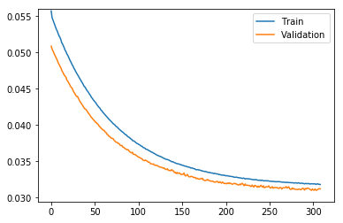

```
Error: 0.08708970055371336
```

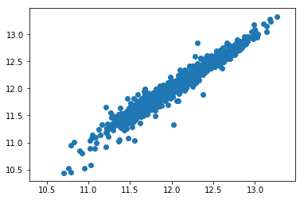

```python
models = [
    BayesianRidge(),
    Lasso(alpha =0.0005),
    ElasticNet(alpha=0.0005, l1_ratio=.9),
    lgb.LGBMRegressor(objective='regression',num_leaves=5,
                      learning_rate=0.05, n_estimators=720,
                      max_bin = 55, bagging_fraction = 0.8,
                      bagging_freq = 5, feature_fraction = 0.2319,
                      feature_fraction_seed=9, bagging_seed=9,
                      min_data_in_leaf =6, min_sum_hessian_in_leaf = 11)
]

ensemble = Ensemble(models)
ensemble.fit(data_train, target)
predictions = ensemble.predict(data_train)

plt.scatter(predictions, target)
plt.xlim(min(min(predictions), min(target)) - 0.15,
         max(max(predictions), max(target)) + 0.15)
plt.ylim(min(min(predictions), min(target)) - 0.15,
         max(max(predictions), max(target)) + 0.15)
print('Error: ' + str(np.sqrt(mean_squared_error(predictions, target))))
```

## Submissão dos resultados

```python
model = ensemble

submission = pd.DataFrame()
submission['Id'] = test_ids

predictions = model.predict(data_test)
final_predictions = np.expm1(predictions) * neighborhood_test/100

submission['SalePrice'] = final_predictions

submission.to_csv('submission.csv', index=False)
```